# Projections and Distortions

Chris Dsida

9/23/2020

In this assignment, I will be looking at subareas (countries) within the continent of South America.

[figure not shown]

“The projection does a good job preserving both distance and azimuth, at the cost of really exaggerating how many South Americas there are.” Source: xkcd.com/2256/

```r
# Load relevant packages
library(ggplot2)
library(sf)
library(rnaturalearth)
library(rnaturalearthdata)
library(tidyverse)
library(ggspatial)
library(cartogram)
library(ggthemes)
```

After loading the necessary packages, I created a simple map of South America, shown below. This uses data from the `rnaturalearth` package to draw borders. I actually don’t want this to count as one of my projections, but would like to use it to demonstrate a potential limitation of this package.

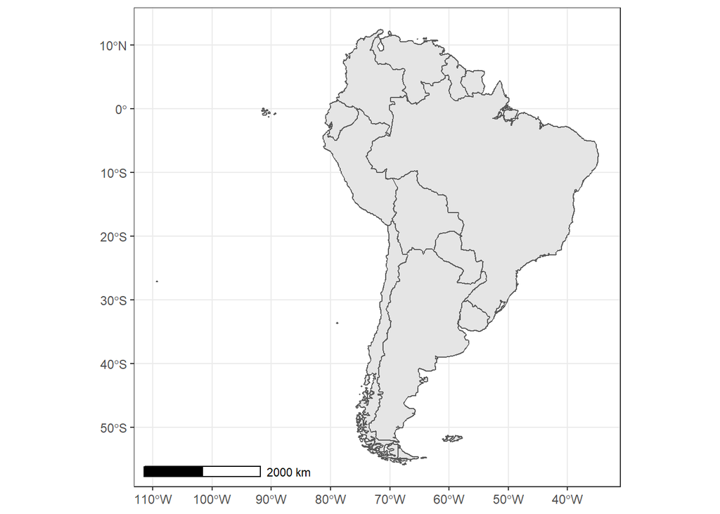

```r
# Create object for South American countries and plot
sa_countries <- ne_countries(scale = 50, continent = "South America", returnclass = "sf")

sa_map <- ggplot(sa_countries) +
  geom_sf() +
  theme_bw()

sa_map +
  annotation_scale()
```

Things look pretty good. However, it appears the the entries under “South America” do not include French Guiana. As we can see below, it’s actually categorized in `rnaturalearth` as France. (which is correct; it’s even part of the EU!)

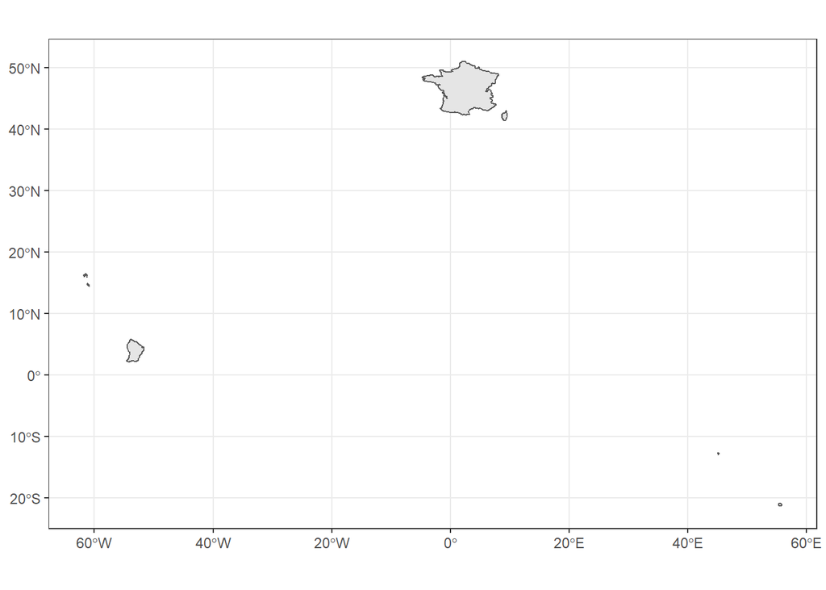

```r
# Map of France, showing overseas departments
fra <- ne_countries(scale = 50, country = "France", returnclass = "sf")

fra_map <- ggplot(fra)+
  geom_sf() +
  theme_bw()

fra_map
```

For comparing projections though, I do want to include all of South America, and incorporated French Guiana into my plot. I tried to figure out how to merge this entry with the rest of `sa_countries`, but didn’t have much luck since the entries for states and countries have different variables attached to them.

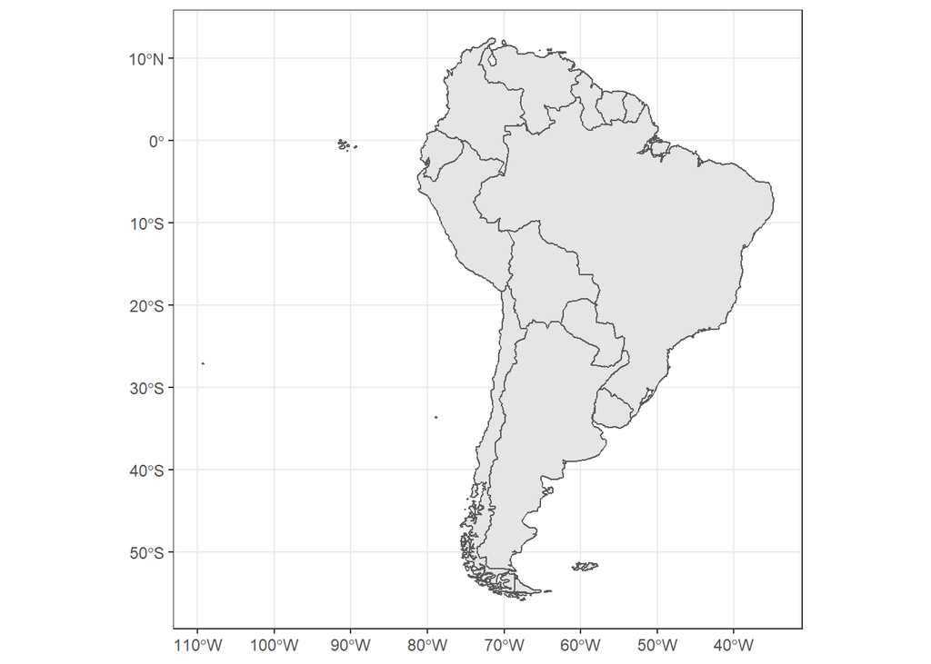

```r
# Combining sf objects in ggplot for complete South America map
fr_gui <- ne_states(country = 'france', returnclass = "sf") %>%
  filter(name_en == "French Guiana")

sa_map_complete <- ggplot() +
  geom_sf(data = sa_countries) +
  geom_sf(data = fr_gui) +
  theme_bw()

sa_map_complete
```

Success!

# Projection 1: UTM

The first projection I wanted to explore was a Universal Transverse Mercator, centered over Chile. (zone 19S, found on spatialreference.org) The farther away from the central meridian one looks, the more that cardinal directions and latitudinal distance become distorted. This seems like it could work well for relatively “narrow” countries.

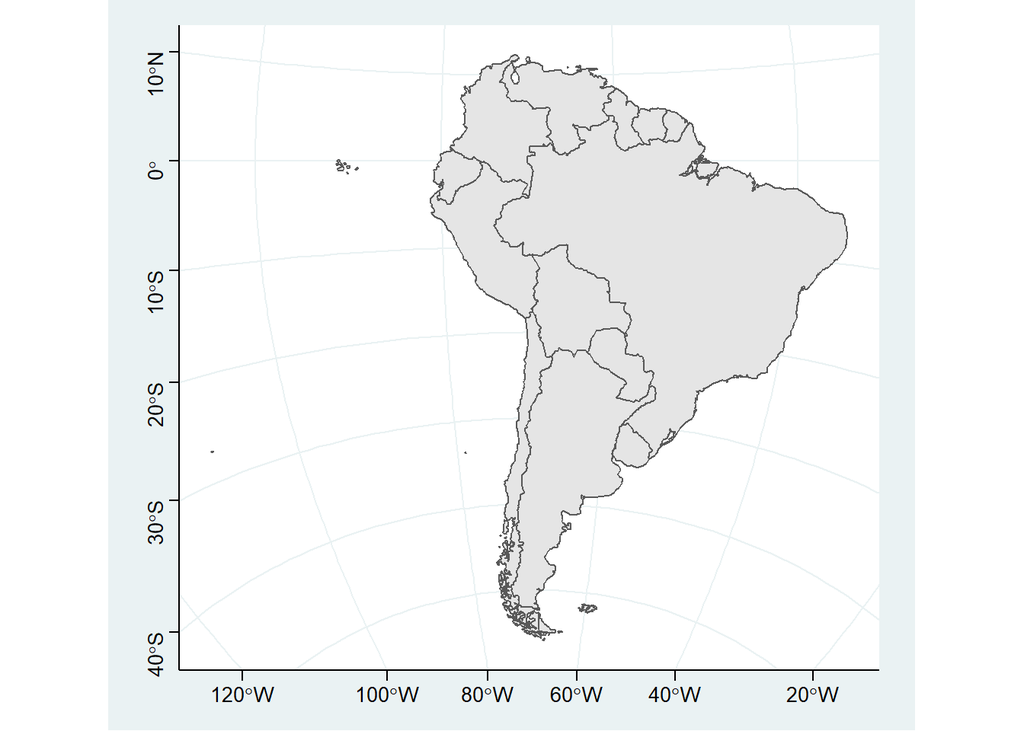

```r
# Mapping South America with UTM projection
chl_pro <- "+proj=utm +zone=19 +south +ellps=aust_SA +towgs84=-67.35,3.88,-38.22,0,0,0,0 +units=m +no_defs"

ggplot() +
  geom_sf(data = sa_countries) +
  geom_sf(data = fr_gui) +
  coord_sf(crs = chl_pro) +
  theme_stata()
```

# Projection 2: AEA Conical

Next up is an equal-area projection centered above Brazil. (also from spatialreference.org) This seems to do a better job preserving area and direction (or at least the coordinate grid appears more parallel). At the same time, shapes are a bit distorted (stretched horizontally), especially at the northern and southern extents of the map.

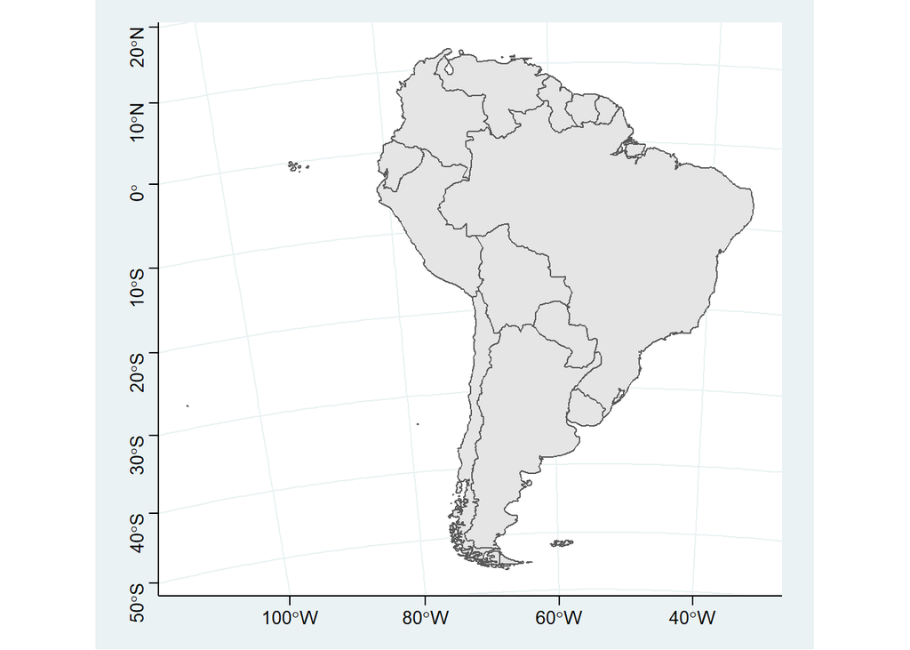

```r
# Mapping South America with AEA projection
brz_pro <- "+proj=aea +lat_1=-2 +lat_2=-22 +lat_0=-12 +lon_0=-54 +x_0=0 +y_0=0 +ellps=aust_SA +units=m +no_defs"


ggplot() +
  geom_sf(data = sa_countries) +
  geom_sf(data = fr_gui) +
  coord_sf(crs = brz_pro) +
  theme_stata()
```

# Projection 3: A Bad Idea

Lastly, we can see what happens when using a projection that is intended for a totally different part of the world. This is the Washington State plane projection from the written tutorial. Obviously, this does a poor job of preserving anything of value for this map, but it is kind of funny!

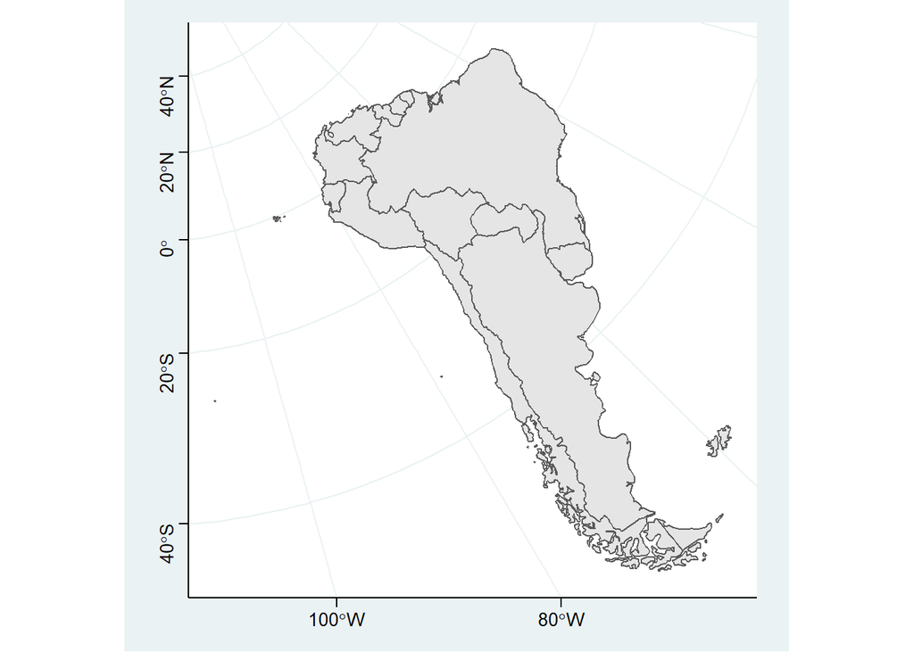

```r
# Dumb projection
wa_pro <- "+proj=lcc +lat_1=47.5 +lat_2=48.73333333333333 +lat_0=47 +lon_0=-120.8333333333333 +x_0=500000 +y_0=0 +ellps=GRS80 +units=m +no_defs"

ggplot() +
  geom_sf(data = sa_countries) +
  geom_sf(data = fr_gui) +
  coord_sf(crs = wa_pro) +
  theme_stata()
```

# Representing a Variable

I have decided to look at rates of COVID-19 in South America. Unfortunately, data for French Guiana is usually reported with France (I checked several places), so I will have to leave it out.

```r
# importing and joining WHO covid-19 data to existing country dataframe
covid_data <- read.csv(file = "WHO-COVID-19-global-data.csv")

covid_sa <- sa_countries %>%
  left_join(covid_data, by = c("name_long" = "Country")) %>%
  mutate(case_100k = 100000 * Cumulative_cases / pop_est,
         gdp_per_cap = gdp_md_est * 1000000 / pop_est) %>%
  select(name_long, pop_est, case_100k, New_cases, Cumulative_cases, New_deaths, Cumulative_deaths, gdp_per_cap, abbrev)
```

Here is a pretty straightforward plot where the fill color is determined by the rate of COVID 19 cases per 100,000 residents.

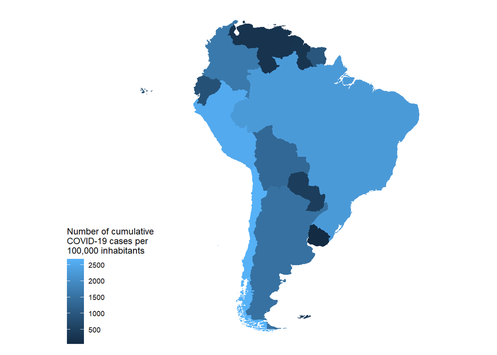

```r
# plotting rates of COVID
ggplot(covid_sa, aes(fill = case_100k)) +
  geom_sf(color = NA) +
  coord_sf(crs = brz_pro) +
  scale_fill_continuous(name = "Number of cumulative \nCOVID-19 cases per \n100,000 inhabitants") +
  theme_map()
```

Besides just showing different rates of COVID cases with color, I decided to also use the size of each country to show GDP per capita. (I removed the Falklands/Malvinas because their absurdly high gdp per capita ruined any sense of scale). Though this depiction does not focus on geography, it could be useful as a stripped-down comparison of these two variables. That being said, it doesn’t seem like a country’s wealth has an obvious impact on the rate of infection.

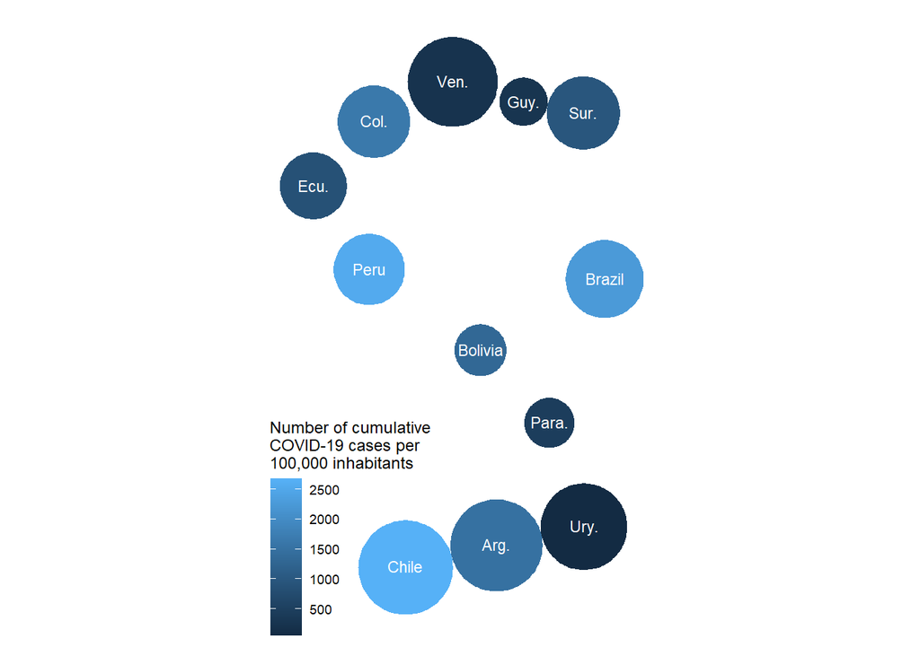

```r
# Non-continuous cartogram
covid_sa_transformed <- covid_sa %>%
  st_transform(crs = brz_pro) %>%
  filter(name_long != "Falkland Islands")

covid_cartogram <- covid_sa_transformed %>%
  cartogram_dorling("gdp_per_cap")

ggplot(covid_cartogram, aes(fill = case_100k)) +
  geom_sf(color = NA) +
  scale_fill_continuous(name = "Number of cumulative \nCOVID-19 cases per \n100,000 inhabitants") +
  theme_map() +
  geom_sf_text(aes(geometry, label = abbrev), size = 3, color = "white") +
  theme(legend.background = element_blank())
```

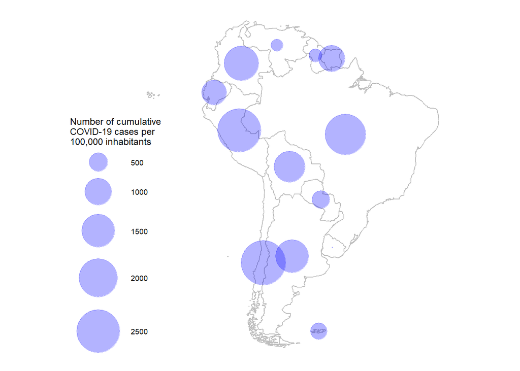

```r
# Need to bring back the Falklands/Malvinas into the dataframe first, overwriting the modified one
covid_sa_transformed <- covid_sa %>%
  st_transform(crs = brz_pro)

# Proportional symbol map
covid_centroids <- covid_sa_transformed %>%
  st_centroid()

ggplot(covid_sa_transformed) +
  geom_sf(fill = NA, color = "gray") +
  geom_sf(data = covid_centroids,
          aes(size = case_100k),
          color = "blue",
          alpha = 0.3) +
  scale_size_continuous(name = "Number of cumulative \nCOVID-19 cases per \n100,000 inhabitants",
                        breaks = seq(500, 2500, by = 500),
                        labels = formatC(seq(500, 2500, by = 500)),
                        range = c(0, 20)) +
  theme_map()
```